# exercise_1

## Question 2: Understanding and Handling Noise

The goal here is to understand filters across noise types and content types.

### (2a) Noise robustness comparison

Corrupt the grayscale image **f3** with three noise types:

- Gaussian noise (use np.random.normal)
- Salt-and-pepper noise (randomly set pixels to 0 or 255)
- Impulse noise (randomly set pixels to 255 only)

Apply both a Gaussian filter and a median filter to each noisy image.

Visualize each noise type × filter and discuss: which filter is suitable for which noise type, and why based on the properties of each filter?

Compute PSNR (peak signal-to-noise ratio) against the clean original for all combinations. Validate you observations (Higher the PSNR value, lower the noise).

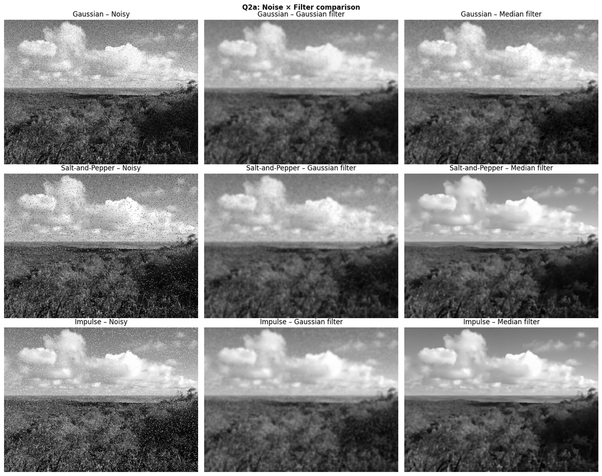

```
                        Noisy   + Gaussian   + Median
-------------------------------------------------------
Gaussian                20.53        25.99      25.65  dB
Salt-and-Pepper         17.97        25.53      26.84  dB
Impulse                 17.42        24.49      26.88  dB
```

```python
np.random.seed(42)

# --- Add noise ---
def add_gaussian_noise(img, std=25):
    noise = np.random.normal(0, std, img.shape)
    return np.clip(img + noise, 0, 255)

def add_salt_and_pepper(img, prob=0.05):
    noisy = img.copy()
    mask = np.random.rand(*img.shape)
    noisy[mask < prob / 2] = 0
    noisy[mask > 1 - prob / 2] = 255
    return noisy

def add_impulse_noise(img, prob=0.05):
    noisy = img.copy()
    mask = np.random.rand(*img.shape) < prob
    noisy[mask] = 255
    return noisy

f3_gauss_noisy  = add_gaussian_noise(f3)
f3_sp_noisy     = add_salt_and_pepper(f3)
f3_imp_noisy    = add_impulse_noise(f3)

noise_types = ['Gaussian', 'Salt-and-Pepper', 'Impulse']
noisy_imgs  = [f3_gauss_noisy, f3_sp_noisy, f3_imp_noisy]

# --- Apply filters ---
gauss_filtered = [cv2.GaussianBlur(n, (0,0), 2.0) for n in noisy_imgs]
med_filtered   = [cv2.medianBlur(n.astype(np.uint8), 5).astype(np.float64) for n in noisy_imgs]

# --- Visualise ---
fig, axes = plt.subplots(3, 3, figsize=(15, 12))
titles_col = ['Noisy', 'Gaussian filter', 'Median filter']
for row, (name, noisy, gf, mf) in enumerate(zip(noise_types, noisy_imgs, gauss_filtered, med_filtered)):
    for col, (img, title) in enumerate(zip([noisy, gf, mf], titles_col)):
        axes[row, col].imshow(img, cmap='gray', vmin=0, vmax=255)
        axes[row, col].set_title(f'{name} – {title}')
        axes[row, col].axis('off')
plt.suptitle('Q2a: Noise × Filter comparison', fontweight='bold')
plt.tight_layout()
plt.show()

# --- PSNR table ---
print(f'{"":20s} {"Noisy":>8s} {"+ Gaussian":>12s} {"+ Median":>10s}')
print('-' * 55)
for name, noisy, gf, mf in zip(noise_types, noisy_imgs, gauss_filtered, med_filtered):
    p_noisy = psnr(f3, noisy)
    p_gf    = psnr(f3, gf)
    p_mf    = psnr(f3, mf)
    print(f'{name:20s} {p_noisy:8.2f} {p_gf:12.2f} {p_mf:10.2f}  dB')

# Discussion:
# - Gaussian noise: Gaussian filter reduces it well (it averages out zero-mean noise).
#   Median also helps but Gaussian blur wins on PSNR for this noise type.
# - Salt-and-pepper: Median filter is far superior. The median selects the central
#   rank value and simply ignores isolated extreme (0/255) pixels. Gaussian
#   averaging spreads the extreme values into neighbouring pixels, preserving
#   their influence and performing poorly.
# - Impulse noise (salt only): Same reasoning as S&P – median excels because
#   each impulse is an isolated outlier that the median rank discards entirely.
```

### (2b) Morphological filters for noise removal

Corrupt **f4** with salt-and-pepper noise. Apply morphological opening, closing, and opening+closing using structuring elements of 2 different sizes.

Answer:

- Which operation is necessary for salt noise, and pepper noise individually and combined?
- What happens to fine image structures as structuring element size increases?
- Can you combine morphological filtering with a subsequent Gaussian to further improve quality? Try it and show the result.

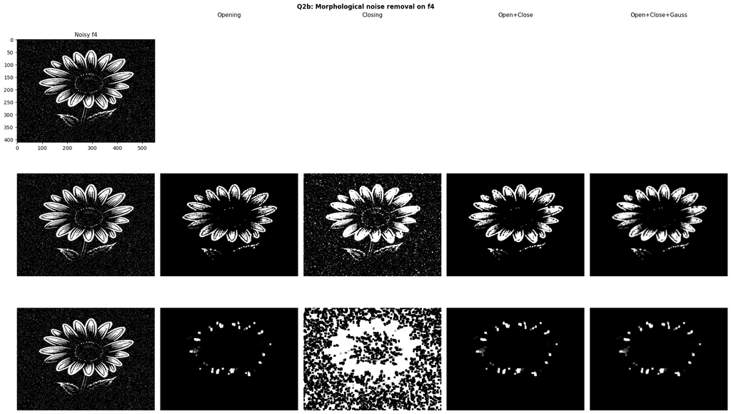

```python
np.random.seed(42)

# Corrupt f4 with salt-and-pepper noise
def add_sp_noise(img, prob=0.05):
    noisy = img.copy()
    r = np.random.rand(*img.shape)
    noisy[r < prob / 2] = 0
    noisy[r > 1 - prob / 2] = 255
    return noisy

f4_noisy = add_sp_noise(f4, prob=0.08).astype(np.uint8)

# Structuring elements
se3 = cv2.getStructuringElement(cv2.MORPH_RECT, (3, 3))
se7 = cv2.getStructuringElement(cv2.MORPH_RECT, (7, 7))

results = {}
for label, se in [('3×3', se3), ('7×7', se7)]:
    opened  = cv2.morphologyEx(f4_noisy, cv2.MORPH_OPEN,  se)
    closed  = cv2.morphologyEx(f4_noisy, cv2.MORPH_CLOSE, se)
    oc      = cv2.morphologyEx(opened,   cv2.MORPH_CLOSE, se)
    oc_gauss = cv2.GaussianBlur(oc.astype(np.float64), (0,0), 1.0)
    results[label] = (opened, closed, oc, oc_gauss)

fig, axes = plt.subplots(3, 5, figsize=(20, 12))
col_titles = ['Noisy f4', 'Opening', 'Closing', 'Open+Close', 'Open+Close+Gauss']
for col, t in enumerate(col_titles):
    axes[0, col].set_title(t, fontsize=11)

for row, (label, se) in enumerate([('3×3', se3), ('7×7', se7)], start=1):
    opened, closed, oc, oc_gauss = results[label]
    for col, img in enumerate([f4_noisy, opened, closed, oc, oc_gauss]):
        axes[row, col].imshow(img, cmap='gray', vmin=0, vmax=255)
        axes[row, col].set_ylabel(f'SE {label}', fontsize=10)
        axes[row, col].axis('off')

axes[0, 0].imshow(f4_noisy, cmap='gray', vmin=0, vmax=255)
for col in range(1, 5):
    axes[0, col].axis('off')

plt.suptitle('Q2b: Morphological noise removal on f4', fontweight='bold')
plt.tight_layout()
plt.show()

# Answers:
# - Salt noise (white dots)  → Opening (erosion then dilation) removes isolated
#   bright pixels because erosion shrinks bright regions and dilation only
#   restores large bright areas.
# - Pepper noise (black dots) → Closing (dilation then erosion) removes isolated
#   dark pixels with the dual argument.
# - Combined salt-and-pepper  → Opening followed by Closing (or vice versa)
#   handles both.
# - Larger SE removes more noise but also erodes fine image structures
#   (thin edges, small features shrink or disappear) because the structuring
#   element is larger than the features themselves.
# - Adding a light Gaussian after morphological filtering smooths residual
#   staircase artefacts introduced at boundaries by the erosion/dilation steps,
#   improving visual quality and often raising PSNR.
```

## Question 3 - Fourier Transformations

The goal here is to understand the effects of Fourier transforms and operations in the Fourier space.

### (3a) Fourier Transform

Compute the 2D Fourier Transform of **f2** and **f3**. Visualize the log magnitude spectrum of both.

1. What differences do you observe between the frequency spectra of the checkerboard and the natural image?
2. What does this tell you about their spatial structure?

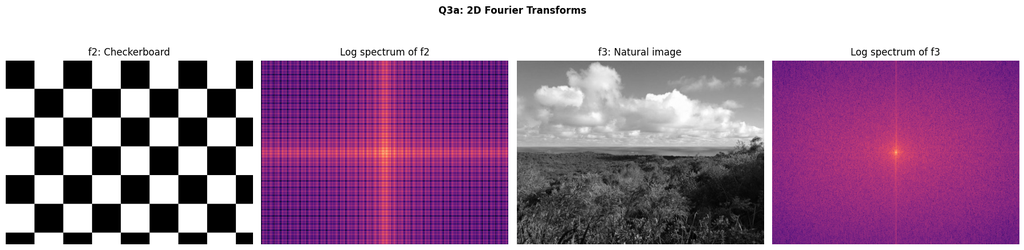

```python
def compute_log_spectrum(img):
    F = np.fft.fft2(img)
    F_shifted = np.fft.fftshift(F)
    magnitude = np.abs(F_shifted)
    return np.log1p(magnitude)

spec_f2 = compute_log_spectrum(f2)
spec_f3 = compute_log_spectrum(f3)

fig, axes = plt.subplots(1, 4, figsize=(18, 5))
axes[0].imshow(f2, cmap='gray', vmin=0, vmax=255)
axes[0].set_title('f2: Checkerboard')
axes[0].axis('off')
axes[1].imshow(spec_f2, cmap='magma')
axes[1].set_title('Log spectrum of f2')
axes[1].axis('off')
axes[2].imshow(f3, cmap='gray', vmin=0, vmax=255)
axes[2].set_title('f3: Natural image')
axes[2].axis('off')
axes[3].imshow(spec_f3, cmap='magma')
axes[3].set_title('Log spectrum of f3')
axes[3].axis('off')
plt.suptitle('Q3a: 2D Fourier Transforms', fontweight='bold')
plt.tight_layout()
plt.show()

# Observations:
# 1. f2 (checkerboard) shows a sparse, symmetric pattern of bright spots
#    (impulses) in the frequency domain arranged on a regular grid corresponding
#    to the fundamental tile frequency and its harmonics. Energy is concentrated
#    at specific discrete frequencies.
#    f3 (natural image) shows a continuous, broadband spectrum that decays
#    smoothly from the centre (DC) outwards with higher energy along the
#    horizontal and vertical axes (corresponding to dominant edge orientations).
# 2. The checkerboard is a periodic signal so its Fourier representation is
#    a comb of delta-like spikes. Natural images contain structures at all scales
#    and orientations, producing energy spread across the entire frequency plane
#    following a roughly 1/f² power-law fall-off.
```

### (3b) Effect of Gaussian Blur

Apply Gaussian blur to both images **f2** and **f3**. Compute and visualize their log magnitude spectrum again.

1. How does Gaussian blur affect the frequency spectrum?
2. Exlain why these changes occur in frequency space.

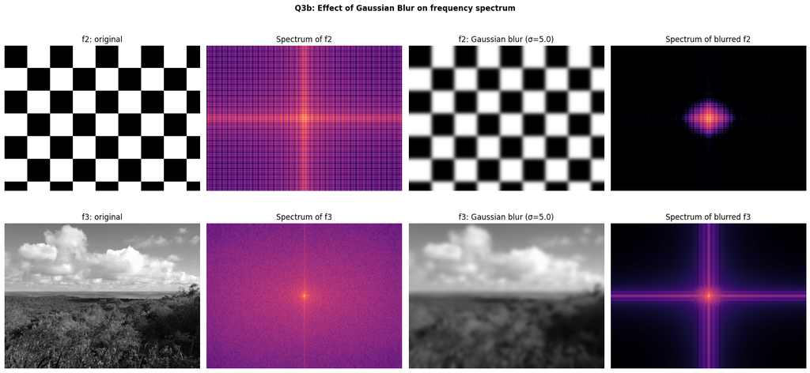

```python
sigma_3b = 5.0

f2_blurred = cv2.GaussianBlur(f2, (0, 0), sigma_3b)
f3_blurred = cv2.GaussianBlur(f3, (0, 0), sigma_3b)

spec_f2_blur = compute_log_spectrum(f2_blurred)
spec_f3_blur = compute_log_spectrum(f3_blurred)

fig, axes = plt.subplots(2, 4, figsize=(18, 9))
for row, (orig, blurred, spec_orig, spec_blur, name) in enumerate([
    (f2, f2_blurred, spec_f2, spec_f2_blur, 'f2'),
    (f3, f3_blurred, spec_f3, spec_f3_blur, 'f3'),
]):
    axes[row, 0].imshow(orig,    cmap='gray', vmin=0, vmax=255)
    axes[row, 0].set_title(f'{name}: original')
    axes[row, 0].axis('off')
    axes[row, 1].imshow(spec_orig, cmap='magma')
    axes[row, 1].set_title(f'Spectrum of {name}')
    axes[row, 1].axis('off')
    axes[row, 2].imshow(blurred,  cmap='gray', vmin=0, vmax=255)
    axes[row, 2].set_title(f'{name}: Gaussian blur (σ={sigma_3b})')
    axes[row, 2].axis('off')
    axes[row, 3].imshow(spec_blur, cmap='magma')
    axes[row, 3].set_title(f'Spectrum of blurred {name}')
    axes[row, 3].axis('off')
plt.suptitle('Q3b: Effect of Gaussian Blur on frequency spectrum', fontweight='bold')
plt.tight_layout()
plt.show()

# Observations:
# 1. Gaussian blur suppresses high-frequency components: the outer (high-freq)
#    regions of the magnitude spectrum become much darker after blurring.
#    For f2, the high-frequency checkerboard harmonics nearly disappear;
#    for f3, fine edge details are attenuated.
# 2. In frequency space a Gaussian blur is multiplication by a Gaussian envelope
#    (Convolution Theorem: convolution in space ↔ multiplication in frequency).
#    The Gaussian envelope falls off smoothly with frequency, acting as a
#    low-pass filter. A larger σ in space → narrower Gaussian in frequency →
#    more aggressive suppression of high frequencies, matching the perceived
#    blurring in the spatial domain.
```

### (3c) Frequency Filtering

Apply to both images:

- Low-pass filter
- High-pass filter

Observe and analyse:

1. Changes in spatial domain
2. Changes in frequency domain

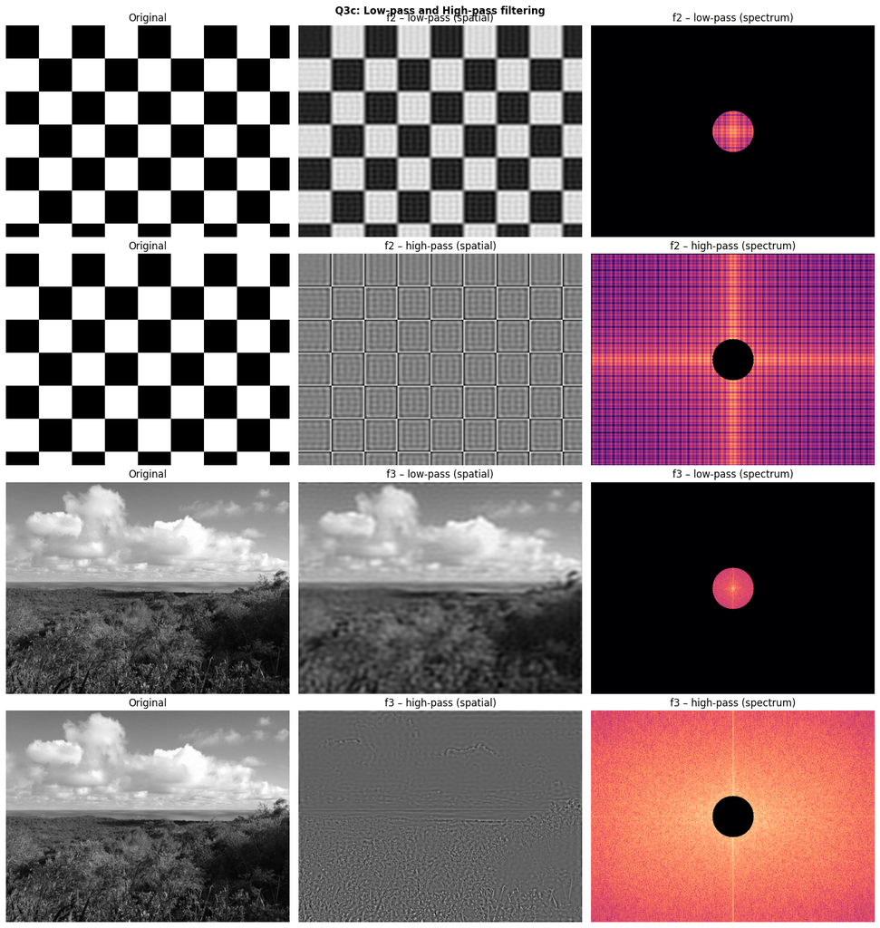

```python
def freq_filter(img, radius, kind='low'):
    """Apply ideal LP or HP filter in frequency domain."""
    F = np.fft.fft2(img)
    Fsh = np.fft.fftshift(F)
    cy, cx = np.array(Fsh.shape) // 2
    Y, X = np.ogrid[:Fsh.shape[0], :Fsh.shape[1]]
    dist = np.sqrt((X - cx)**2 + (Y - cy)**2)
    mask = (dist <= radius) if kind == 'low' else (dist > radius)
    filtered = np.fft.ifft2(np.fft.ifftshift(Fsh * mask)).real
    filtered_spec = np.log1p(np.abs(np.fft.fftshift(np.fft.fft2(filtered))))
    return filtered, filtered_spec

radius = 40

f2_lp, spec_f2_lp = freq_filter(f2, radius, 'low')
f2_hp, spec_f2_hp = freq_filter(f2, radius, 'high')
f3_lp, spec_f3_lp = freq_filter(f3, radius, 'low')
f3_hp, spec_f3_hp = freq_filter(f3, radius, 'high')

fig, axes = plt.subplots(4, 3, figsize=(15, 16))
rows = [
    (f2, spec_f2, f2_lp, spec_f2_lp, 'f2 – low-pass'),
    (f2, spec_f2, f2_hp, spec_f2_hp, 'f2 – high-pass'),
    (f3, spec_f3, f3_lp, spec_f3_lp, 'f3 – low-pass'),
    (f3, spec_f3, f3_hp, spec_f3_hp, 'f3 – high-pass'),
]
for row_idx, (orig, orig_spec, filt, filt_spec, title) in enumerate(rows):
    axes[row_idx, 0].imshow(orig,      cmap='gray')
    axes[row_idx, 0].set_title('Original')
    axes[row_idx, 0].axis('off')
    axes[row_idx, 1].imshow(filt,      cmap='gray')
    axes[row_idx, 1].set_title(title + ' (spatial)')
    axes[row_idx, 1].axis('off')
    axes[row_idx, 2].imshow(filt_spec, cmap='magma')
    axes[row_idx, 2].set_title(title + ' (spectrum)')
    axes[row_idx, 2].axis('off')
plt.suptitle('Q3c: Low-pass and High-pass filtering', fontweight='bold')
plt.tight_layout()
plt.show()

# Spatial domain observations:
# - Low-pass: image looks blurred/smooth; fine details and edges are removed.
#   For f2, the sharp checker transitions become soft gradients.
#   For f3, the scene is recognisable but detail-free.
# - High-pass: only edges and fine textures remain; uniform regions become grey
#   (near zero). For f2 only the tile boundaries survive. For f3 only contours
#   and textures appear.
#
# Frequency domain observations:
# - Low-pass spectrum has energy only inside the circular mask (centre);
#   the outer ring is zeroed – confirms high-freq removal.
# - High-pass spectrum is the complement: zero at centre, energy only outside
#   the mask – confirms low-freq (DC and smooth variations) removal.
```